# 0. Load data, cache, and descriptives

peekbank-items

This notebook loads the **peekbank 2026.1** release, builds the cached intermediates used by the rest of the project, and reports descriptives.

Data loaders are adapted from the `peekbank-development` paper repository (`0_get_data.qmd`). They are reproduced here so this project is self-contained and reproducible against a fixed release. The heavy database pulls are guarded: they only run if the cache file is missing, so re-rendering is fast.

```r
library(here)
library(peekbankr)
library(dtplyr)
library(fuzzyjoin)
source(here("helper", "common.R"))
source(here("helper", "rt_helper.R"))
knitr::opts_chunk$set(cache = FALSE)  # we cache via saveRDS; knitr cache chokes on long vectors

DB_VERSION <- "2026.1"

# minimum trials to retain a participant (used downstream in notebook 1)
ACC_MIN_TRIAL_CUTOFF <- 4
RT_MIN_TRIAL_CUTOFF <- 2

# location of the small/precise item-level CDI subset (standard_model_2)
SM2_PEEKBANK <- here("..", "..", "standard_model_2", "data", "peekbank")
```

## Pull raw data from the database

We pre-filter for age (<= 60 mo), English, and vanilla trials to keep the RAM footprint manageable.

```r
raw_aois_path <- here("cached_intermediates", "raw_aois.rds")
joined_path <- here("cached_intermediates", "0_aoi_data_joined.Rds")
# The raw AOI pull is large/slow; skip it entirely if the joined frame exists.
if (!file.exists(raw_aois_path) && !file.exists(joined_path)) {
  con <- connect_to_peekbank(db_version = DB_VERSION)
  all_aoi_timepoints <- get_aoi_timepoints(connection = con, rle = FALSE)
  saveRDS(all_aoi_timepoints, raw_aois_path)
}
```

```r
tables_path <- here("cached_intermediates", "raw_tables.rds")
if (!file.exists(tables_path)) {
  con <- connect_to_peekbank(db_version = DB_VERSION)
  raw_tables <- list(
    stimuli         = collect(get_stimuli(connection = con)),
    administrations = collect(get_administrations(connection = con)),
    subjects        = unpack_aux_data(collect(get_subjects(connection = con))),
    trial_types     = collect(get_trial_types(connection = con)),
    trials          = unpack_aux_data(collect(get_trials(connection = con))),
    datasets        = collect(get_datasets(connection = con))
  )
  saveRDS(raw_tables, tables_path)
}
raw_tables <- readRDS(tables_path)
all_stimuli         <- raw_tables$stimuli
all_administrations <- raw_tables$administrations
all_subjects        <- raw_tables$subjects
all_trial_types     <- raw_tables$trial_types
all_trials          <- raw_tables$trials
all_datasets        <- raw_tables$datasets
```

## Join AOI timepoints with metadata

```r
if (!file.exists(joined_path)) {
  all_aoi_timepoints <- readRDS(raw_aois_path)
  aoi_data_joined <- all_aoi_timepoints |>
    inner_join(all_administrations |>
      select(dataset_name, dataset_id, subject_id, administration_id, age) |>
      filter(age <= 60)) |>
    inner_join(all_trials |>
      select(dataset_name, dataset_id, trial_id, trial_type_id, trial_order)) |>
    inner_join(all_trial_types |>
      select(dataset_name, dataset_id, trial_type_id, target_id, distractor_id,
             target_side, vanilla_trial, full_phrase_language) |>
      filter(vanilla_trial == TRUE, full_phrase_language == "eng")) |>
    mutate(stimulus_id = target_id) |>
    left_join(all_stimuli |>
      select(dataset_name, dataset_id, stimulus_id, english_stimulus_label)) |>
    select(dataset_name, subject_id, administration_id, trial_id, trial_order,
           dataset_id, full_phrase_language, stimulus_id, distractor_id, t_norm,
           age, aoi, english_stimulus_label, target_side, vanilla_trial) |>
    rename(target_label = english_stimulus_label, target_id = stimulus_id) |>
    left_join(all_stimuli |>
      select(stimulus_id, dataset_id, english_stimulus_label) |>
      rename(distractor_id = stimulus_id, distractor_label = english_stimulus_label))
  saveRDS(aoi_data_joined, file = joined_path)
}
aoi_data_joined <- readRDS(joined_path)
```

Datasets present after filtering:

```r
length(unique(aoi_data_joined$dataset_name))
```

```
[1] 30
```

```r
sort(unique(aoi_data_joined$dataset_name))
```

```
 [1] "adams_marchman_2018"       "bacon_gendercues"
 [3] "bergelson_swingley_2012"   "borovsky_2019"
 [5] "byers-heinlein_2017"       "fernald_marchman_2012"
 [7] "fernald_totlot"            "fmw_2013"
 [9] "frank_tablet_2016"         "garrison_bergelson_2020"
[11] "kremin_2021"               "mahr_coartic"
[13] "moore_bergelson_2022_verb" "perry_cowpig"
[15] "pomper_dimy"               "pomper_prime"
[17] "pomper_saffran_2016"       "pomper_salientme"
[19] "pomper_yumme"              "potter_canine"
[21] "potter_remix"              "reflook_socword"
[23] "reflook_v4"                "ronfard_2021"
[25] "sander-montant_2022"       "swingley_aslin_2002"
[27] "weaver_saffran_2026"       "weaver_zettersten_2024"
[29] "yoon_simpimp_2015"         "yurovsky_2017"
```

## Item cleanup

Remove bilingual datasets, code accuracy, and apply the hand-curated item merge/exclude list (`metadata/included_items_2026.1.csv`).

```r
d_joined <- aoi_data_joined |>
  filter(!dataset_name %in% c("sander-montant_2022", "kremin_2021",
                              "byers-heinlein_2017", "potter_remix")) |>
  select(dataset_name, subject_id, administration_id, trial_id, trial_order,
         dataset_id, target_id, t_norm, age, aoi, target_label, distractor_label,
         target_side) |>
  mutate(
    correct = case_when(aoi == "target" ~ 1, aoi == "distractor" ~ 0, TRUE ~ NA),
    target_label = str_to_lower(target_label),
    distractor_label = str_to_lower(distractor_label)
  )

included_items <- read_csv(here("metadata", "included_items_2026.1.csv"))

d_aoi <- d_joined |>
  left_join(included_items, by = join_by(target_label == item)) |>
  left_join(included_items, by = join_by(distractor_label == item),
            suffix = c("_target", "_distractor")) |>
  filter(include_target == 1, include_distractor == 1) |>
  mutate(
    target_label = ifelse(is.na(rename_to_target), target_label, rename_to_target),
    distractor_label = ifelse(is.na(rename_to_distractor), distractor_label, rename_to_distractor)
  ) |>
  select(-include_target, -include_distractor, -rename_to_distractor, -rename_to_target)
```

## Timecourse cleanup

Clip to a common [-4000, 4000] ms window. (Datasets vary in missingness due to internal exclusions, data extent, and NA padding.)

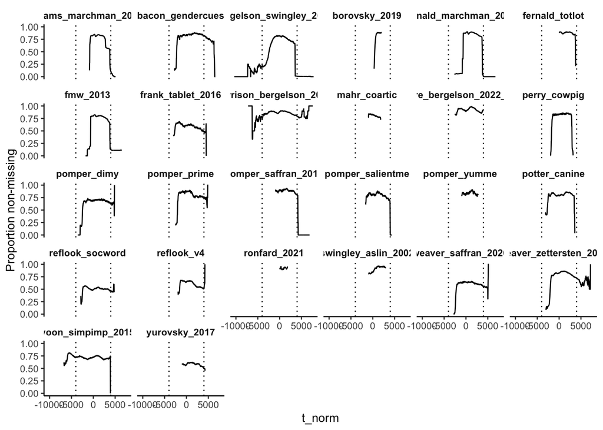

```r
d_missing <- d_aoi |>
  group_by(dataset_name, t_norm) |>
  summarise(prop_data = mean(!is.na(correct)), n = n())

ggplot(d_missing, aes(x = t_norm, y = prop_data)) +
  facet_wrap(~dataset_name) +
  geom_line() +
  geom_vline(xintercept = c(-4000, 4000), lty = 3) +
  ylab("Proportion non-missing")
```

```r
d_aoi <- d_aoi |> filter(t_norm >= -4000, t_norm <= 4000)
saveRDS(d_aoi, file = here("cached_intermediates", "0_d_aoi.Rds"))
```

## CDI summary scores

Peekbank’s CDI aux data contains only **summary scores** (total rawscore per administration), not item-level responses. We compute a CDI percent (rawscore / instrument length) and fuzzy-join to the LWL administrations on subject and age (max age distance = 1 mo), averaging when an LWL admin matches multiple CDIs.

```r
admin_info <- all_administrations |>
  distinct(subject_id, dataset_id, administration_id, age) |>
  left_join(all_datasets |> select(dataset_id, dataset_name))

eng_cdi_admins <- all_subjects |>
  unnest(subject_aux_data) |>
  filter(!is.na(cdi_responses)) |>
  unnest(cdi_responses) |>
  filter(language == "English (American)") |>
  mutate(
    instrument_length = case_when(
      instrument_type == "ws" ~ 680,
      instrument_type == "wg" ~ 396,
      instrument_type == "wsshort" ~ 100,
      instrument_type == "wgshort" ~ 100,
      .default = NA
    ),
    CDI_percent = rawscore / instrument_length
  ) |>
  select(subject_id, age, measure, CDI_percent) |>
  pivot_wider(names_from = "measure", values_from = "CDI_percent",
              values_fill = NA, values_fn = mean)

# fuzzy join: scale subject_id by 10 so off-by-one age can't cross subjects
cdi_data <- fuzzyjoin::difference_left_join(
  mutate(admin_info, subject_id = 10 * subject_id),
  mutate(eng_cdi_admins, subject_id = 10 * subject_id),
  by = c("subject_id", "age"), max_dist = 1
) |>
  select(-age.y, -subject_id.y) |>
  rename(age = age.x, subject_id = subject_id.x) |>
  mutate(subject_id = subject_id / 10) |>
  group_by(subject_id, administration_id, dataset_name, age) |>
  summarise(prod = mean(prod, na.rm = TRUE), comp = mean(comp, na.rm = TRUE)) |>
  mutate(across(c("prod", "comp"), ~ ifelse(is.nan(.x), NA, .x))) |>
  ungroup()

saveRDS(cdi_data, file = here("cached_intermediates", "0_cdi_subjects.Rds"))
```

## Item-level CDI subset (small / precise pathway)

For the linking analyses we have two pathways:

- **Large / noisy** — all children, but CDI is only a summary score, so per-word knowledge must be *imputed* (child ability × word difficulty; notebook 5).
- **Small / precise** — a subset with true **item-level** CDI responses, sourced from `standard_model_2`. Here we know whether each child produced each word (notebook 6).

The precise subset links peekbank administrations to Stanford lab CDI records. Note: the `peekbank_admin_id` in the standard_model_2 link file was generated from a **2022** pull and does not match 2026.1 admin IDs, so we bridge on the release-stable **`lab_subject_id`** instead (saved here as `0_subject_map`).

```r
# subject_id <-> lab_subject_id, the stable bridge to external item-level CDI
subject_map <- all_subjects |>
  distinct(subject_id, lab_subject_id) |>
  mutate(lab_subject_id = as.character(lab_subject_id))
saveRDS(subject_map, here("cached_intermediates", "0_subject_map.Rds"))
```

```r
cdi_items_long <- read_csv(file.path(SM2_PEEKBANK, "stanford_cdi_items_long.csv"))
linked <- read_csv(file.path(SM2_PEEKBANK, "peekbank_stanford_linked.csv"))
item_key <- read_csv(file.path(SM2_PEEKBANK, "cdi_master_item_key.csv"))

saveRDS(list(cdi_items_long = cdi_items_long, linked = linked, item_key = item_key),
        file = here("cached_intermediates", "0_cdi_items_subset.Rds"))

# actual overlap via the stable lab_subject_id bridge
cdi_subs <- unique(as.character(cdi_items_long$lab_subject_id))
lwl_subs_with_cdi <- subject_map |>
  filter(lab_subject_id %in% cdi_subs) |>
  semi_join(d_aoi, by = "subject_id")

tibble(
  quantity = c("children w/ item-level CDI (in standard_model_2)",
               "LWL children matched via lab_subject_id",
               "their LWL administrations",
               "CDI items in key"),
  value = c(length(cdi_subs),
            n_distinct(lwl_subs_with_cdi$subject_id),
            d_aoi |> semi_join(lwl_subs_with_cdi, by = "subject_id") |>
              distinct(administration_id) |> nrow(),
            n_distinct(item_key$item))
) |> kable()
```

| quantity | value |
| --- | --- |
| children w/ item-level CDI (in standard_model_2) | 267 |
| LWL children matched via lab_subject_id | 229 |
| their LWL administrations | 1489 |
| CDI items in key | 752 |

## Descriptives

### Datasets and sample size

```r
d_aoi |>
  group_by(dataset_name) |>
  summarise(
    n_kids = n_distinct(subject_id),
    n_admins = n_distinct(administration_id),
    n_trials = n_distinct(paste(administration_id, trial_id)),
    mean_age = mean(age),
    n_targets = n_distinct(target_label)
  ) |>
  arrange(desc(n_trials)) |>
  kable(digits = 1)
```

| dataset_name | n_kids | n_admins | n_trials | mean_age | n_targets |
| --- | --- | --- | --- | --- | --- |
| adams_marchman_2018 | 69 | 711 | 15265 | 21.9 | 26 |
| fernald_marchman_2012 | 122 | 679 | 11967 | 21.8 | 10 |
| weaver_zettersten_2024 | 141 | 248 | 4959 | 15.8 | 4 |
| fmw_2013 | 80 | 178 | 4884 | 19.7 | 12 |
| fernald_totlot | 63 | 229 | 3744 | 19.4 | 15 |
| reflook_socword | 421 | 421 | 3358 | 33.2 | 4 |
| reflook_v4 | 331 | 331 | 2604 | 36.1 | 8 |
| yurovsky_2017 | 288 | 288 | 2304 | 25.5 | 4 |
| bergelson_swingley_2012 | 84 | 84 | 2081 | 12.0 | 16 |
| weaver_saffran_2026 | 69 | 69 | 1948 | 18.8 | 8 |
| borovsky_2019 | 79 | 79 | 1709 | 18.3 | 12 |
| potter_canine | 67 | 67 | 1628 | 23.9 | 26 |
| yoon_simpimp_2015 | 202 | 202 | 1552 | 42.4 | 10 |
| mahr_coartic | 29 | 29 | 1302 | 20.8 | 10 |
| garrison_bergelson_2020 | 35 | 35 | 1068 | 14.6 | 79 |
| frank_tablet_2016 | 108 | 108 | 864 | 34.0 | 8 |
| pomper_dimy | 82 | 82 | 811 | 16.7 | 11 |
| bacon_gendercues | 38 | 38 | 760 | 22.9 | 10 |
| ronfard_2021 | 40 | 40 | 738 | 20.0 | 8 |
| perry_cowpig | 42 | 42 | 724 | 20.4 | 12 |
| swingley_aslin_2002 | 50 | 50 | 596 | 15.1 | 10 |
| pomper_saffran_2016 | 60 | 60 | 478 | 44.3 | 32 |
| pomper_prime | 25 | 25 | 392 | 40.0 | 16 |
| moore_bergelson_2022_verb | 29 | 29 | 384 | 18.1 | 8 |
| pomper_salientme | 44 | 44 | 262 | 40.1 | 6 |
| pomper_yumme | 37 | 37 | 221 | 39.5 | 5 |

### Overall totals

```r
tibble(
  quantity = c("datasets", "children", "administrations", "trials",
               "unique target words", "unique distractor words"),
  value = c(
    n_distinct(d_aoi$dataset_name),
    n_distinct(d_aoi$subject_id),
    n_distinct(d_aoi$administration_id),
    n_distinct(paste(d_aoi$administration_id, d_aoi$trial_id)),
    n_distinct(d_aoi$target_label),
    n_distinct(d_aoi$distractor_label)
  )
) |> kable()
```

| quantity | value |
| --- | --- |
| datasets | 26 |
| children | 2635 |
| administrations | 4205 |
| trials | 66603 |
| unique target words | 158 |
| unique distractor words | 159 |

### Age distribution

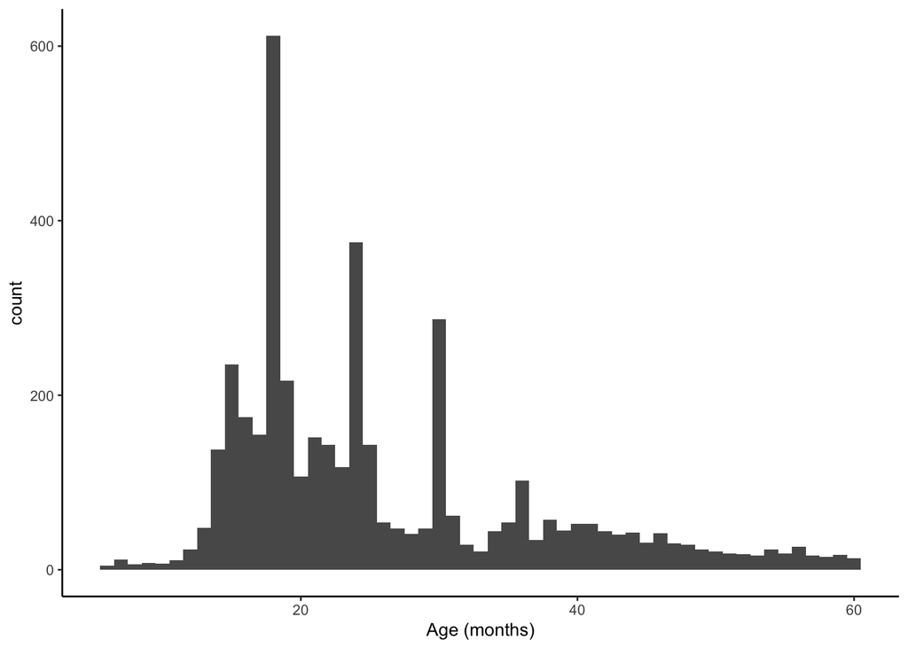

```r
ages <- d_aoi |> group_by(administration_id) |> summarise(age = mean(age))
ggplot(ages, aes(x = age)) +
  geom_histogram(binwidth = 1) +
  xlab("Age (months)")
```

### CDI coverage

How many administrations have a usable CDI summary score?

```r
admins_in_lwl <- d_aoi |> distinct(administration_id)
cdi_data |>
  inner_join(admins_in_lwl) |>
  summarise(
    n_admins = n(),
    has_prod = sum(!is.na(prod)),
    has_comp = sum(!is.na(comp)),
    has_any = sum(!is.na(prod) | !is.na(comp))
  ) |>
  kable()
```

| n_admins | has_prod | has_comp | has_any |
| --- | --- | --- | --- |
| 4205 | 1842 | 748 | 2150 |

### Most frequent target words

```r
d_aoi |>
  distinct(administration_id, trial_id, target_label) |>
  count(target_label, sort = TRUE) |>
  head(25) |>
  kable()
```

| target_label | n |
| --- | --- |
| dog | 9412 |
| book | 5716 |
| cat | 5534 |
| baby | 5414 |
| bird | 5391 |
| car | 4608 |
| ball | 4107 |
| shoe | 3588 |
| juice | 1896 |
| banana | 1735 |
| apple | 1536 |
| fish | 1465 |
| cookie | 1252 |
| frog | 1221 |
| flower | 656 |
| sock | 563 |
| carrot | 432 |
| lamp | 422 |
| horse | 392 |
| duck | 387 |
| milk | 353 |
| clock | 335 |
| cow | 324 |
| toothbrush | 319 |
| tree | 308 |